# 1. 객체 인식률 (조립설명서 내 객체인식 정확률)

### 조립 설명서 내 작업 부품, 지시표지 등 객체 인식(그림, 글자, 문장, 기호 포함) 성공률을 100회 반복하여 성공률을 산출한다.

### 시험 목표: 성공률 90% 이상

1. 시험용 조립설명서 이미지 10장에 대해 객체의 종류와 영역을 추정하는 코드를 실행한다.
2. 코드를 실행하면 조립 설명서 위에 인식한 객체의 종류와 그 영역이 표시된 이미지를 결과물 폴더에 저장하고, 객체 인식 성공률을 출력하는 프로세스가 100회 반복된다.
3. 순서 2에서 100회 반복 출력된 성공률을 확인한다.

### 시험에 사용된 조립설명서 10장

```python
import glob, os
input_img_dir = './input/test/cuts'
input_img_paths = sorted(glob.glob(os.path.join(input_img_dir, '*.png')))
input_img_names = [os.path.basename(path) for path in input_img_paths]

print('Total %d assembly images:' % len(input_img_names))
print(*input_img_names, sep=', ')
```

```
Total 10 assembly images:
ingatorp-08.png, ingolf-07.png, ivar-04.png, ivar-05.png, kaustby-04.png, kaustby-05.png, kaustby-06.png, kaustby-07.png, nordviken-07.png, nordviken-09.png
```

### 객체의 종류

- 딥러닝 기반 인식 대상: 6가지
  - 연결자 (Elements)
  - FP 유발자 (FPTrigger)
  - 원형 말풍선 (Guidance_Circle)
  - 사각형 말풍선 (Guidance_Square)
  - 나무 부품 (Parts)
  - 도구 (Tool)
- Connected component 기반 인식 대상: 1가지
  - 부품번호 및 수량을 나타내는 영역
- OCR 기반 인식 대상: 1가지
  - 부품번호 및 수량

### 성공률 산출 방법

딥러닝 기반 인식 대상 객체들의 mAP, 부품번호 및 수량 영역의 재현율(=Recall), 부품번호 및 수량의 OCR 인식률의 가중 평균을 성공률으로 한다.  
\begin{equation*} score=\frac{1}{8} \Bigl(\sum_{i=1}^6 (AP)_i +\ Recall +\ OCR\;recognition\;rate\Bigr) \end{equation*}

### 코드 실행

```python
%%timeit -n 1 -r 100
%run -i main.py --gpu 3 --iters 1
```

```
----------------
Loading Weights
----------------
INFO:tensorflow:Restoring parameters from ./model/OCR/weight/model.ckpt-90
INFO:tensorflow:Restoring parameters from ./model/OCR/flip_weight/model.ckpt-90
--------------
gpu :  3
--------------

detection start

--------------

detection ended

---------------
evaluation start
---------------
OCR recognition rate: 100.00%
---------------
AP: 78.89% (Elements)
AP: 100.00% (FPTrigger)
AP: 100.00% (Guidance_Circle)
AP: 100.00% (Guidance_Square)
AP: 87.50% (Parts)
AP: 90.00% (Tool)
mAP: 92.73%
---------------
recall for serial & mult bboxes: 100.00%
---------------
Mean score: 94.55%

----------------
Loading Weights
----------------
INFO:tensorflow:Restoring parameters from ./model/OCR/weight/model.ckpt-90
INFO:tensorflow:Restoring parameters from ./model/OCR/flip_weight/model.ckpt-90
--------------
gpu :  3
--------------
```

[output cut: 3146 more lines]

```
OCR recognition rate: 100.00%
---------------
AP: 78.89% (Elements)
AP: 100.00% (FPTrigger)
AP: 100.00% (Guidance_Circle)
AP: 100.00% (Guidance_Square)
AP: 87.50% (Parts)
AP: 90.00% (Tool)
mAP: 92.73%
---------------
recall for serial & mult bboxes: 100.00%
---------------
Mean score: 94.55%

16 s ± 692 ms per loop (mean ± std. dev. of 100 runs, 1 loop each)
```

### 객체 인식 결과 시각화

```python
import matplotlib.pyplot as plt
import numpy as np
from PIL import Image
result_img_paths = sorted(glob.glob(os.path.join('./result_imgs', '*.png')))
def visualize(imgpath):
    imgname = os.path.basename(imgpath)
    img = np.asarray(Image.open(imgpath))[:,:,:3]
    plt.figure(dpi=300)
    plt.imshow(img)
    plt.title(imgname)
    plt.xticks([])
    plt.yticks([])
```

[figure not shown]

```python
visualize(result_img_paths[0])
```

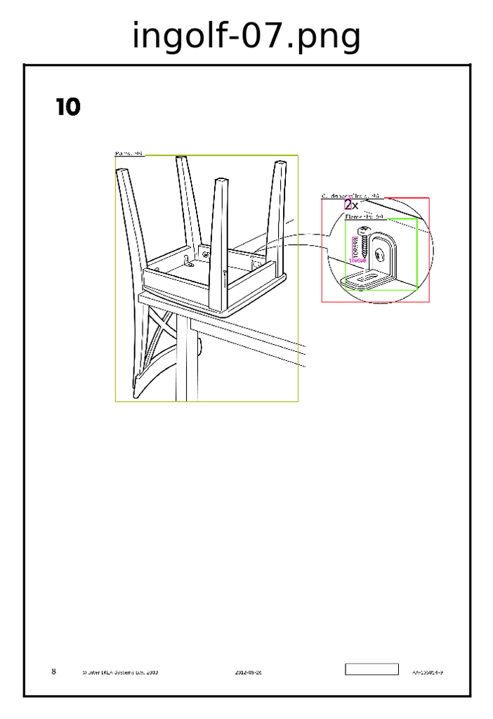

```python
visualize(result_img_paths[1])
```

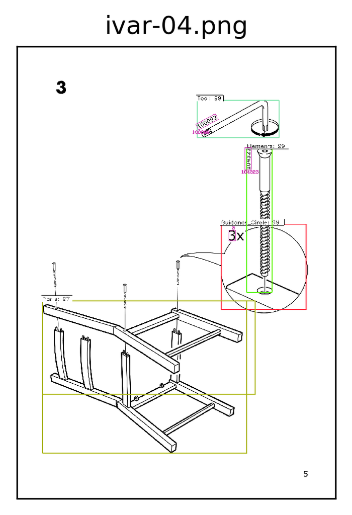

```python
visualize(result_img_paths[2])
```

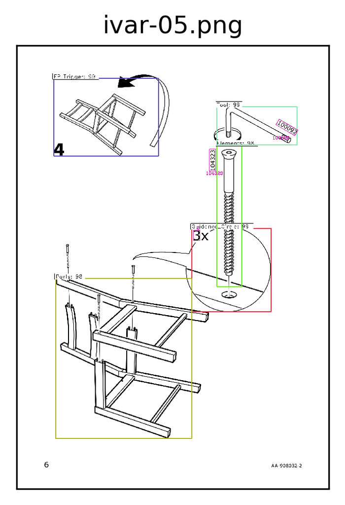

```python
visualize(result_img_paths[3])
```

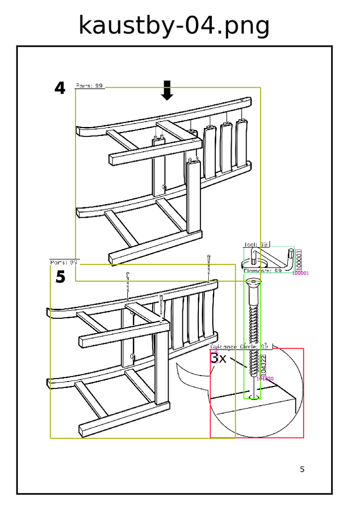

```python
visualize(result_img_paths[4])
```

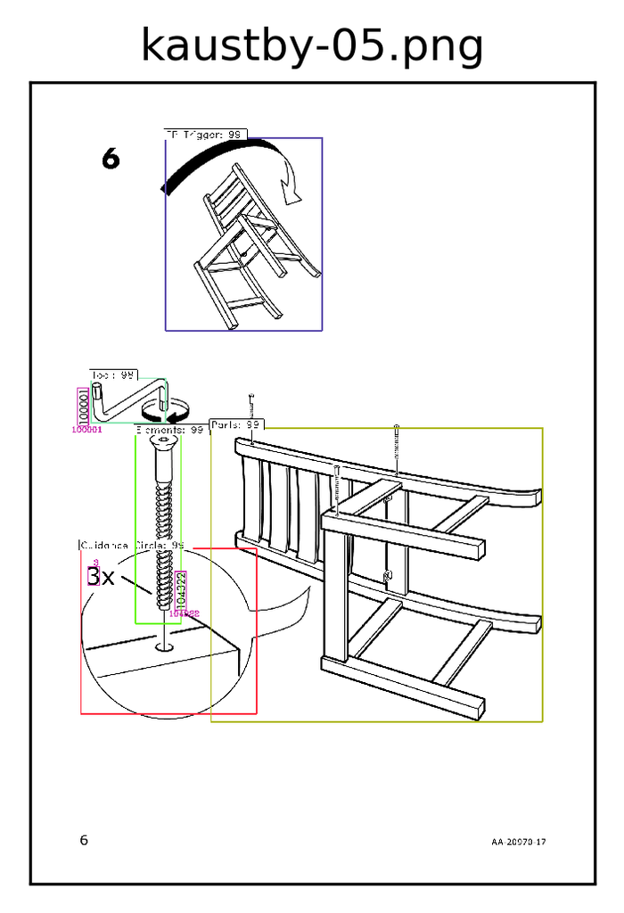

```python
visualize(result_img_paths[5])
```

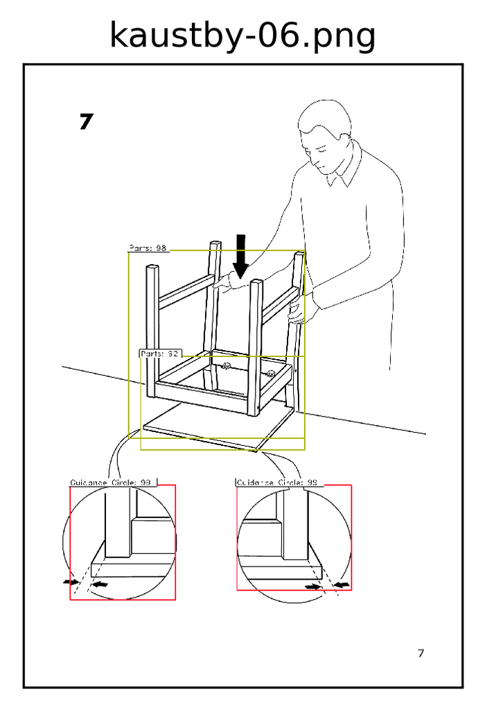

```python
visualize(result_img_paths[6])
```

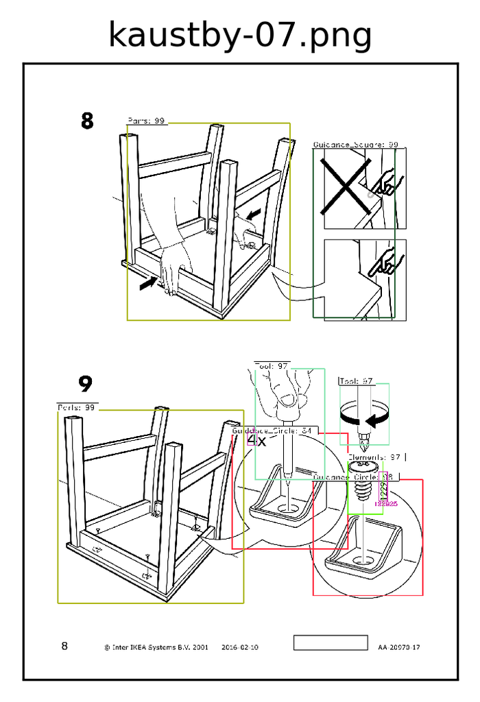

```python
visualize(result_img_paths[7])
```

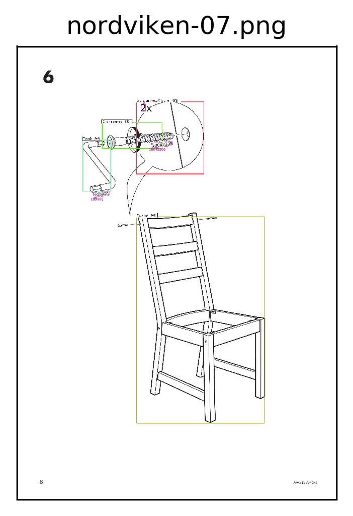

```python
visualize(result_img_paths[8])
```

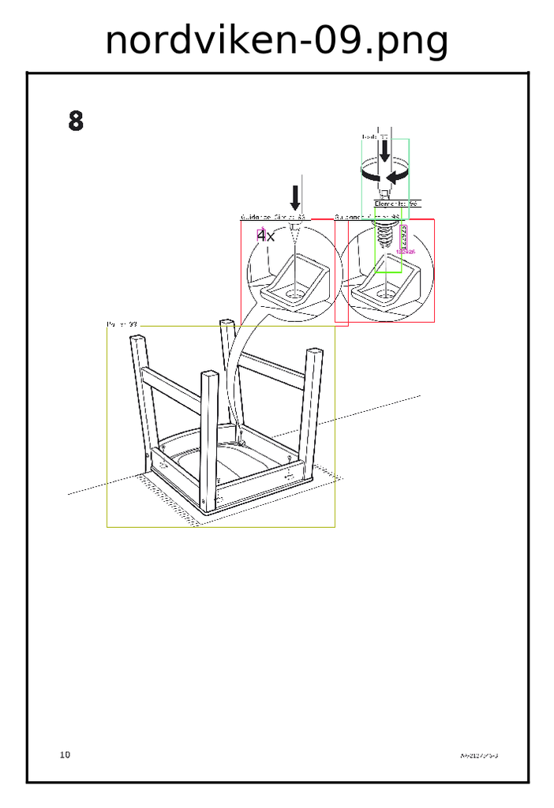

```python
visualize(result_img_paths[9])
```